FINAL PROJECT REPORT · 13 NOVEMBER 2026

# Bioinformatics-Based Analysis of Antimicrobial Resistance in Escherichia coli Using AMRnet Data

Analysis of saved AMRnet outputs, R scripts, statistical tables and project visualisations

Data source: AMRnet public *Escherichia coli* dataset snapshot

## Executive Summary

This report presents an exploratory analysis of AMRnet Escherichia coli records using the supplied R scripts, saved CSV result tables and original project plots. The analysed outputs summarise antimicrobial-resistance marker categories, reported determinants, geographical coverage, missing metadata and a country-by-AMR-status chi-square analysis. The outputs support a database-level descriptive analysis; they do not demonstrate a fresh NCBI genome-download/AMRFinderPlus run or laboratory antimicrobial susceptibility testing.

**Key finding:** Fosfomycin-associated markers are the most frequently represented category in the saved category table (227,610; 87.70%), followed by colistin (170,919; 65.86%). The most frequent determinant is glpT_E448K (223,637), followed by pmrB_Y358N (116,283). The country table contains 137 country labels and 223,675 records with a non-missing country value. The United States contributes the most records (95,008). The saved Pearson chi-square result is statistically significant (X²=305.7, df=9, p<2.2×10⁻¹⁶), while adjusted Cramer's V is 0.04, suggesting a very weak association. The country-level percentages reflect this database extract and must not be interpreted as national prevalence.

## 1. Introduction

Antimicrobial resistance is a major public-health and bioinformatics concern. Genomic surveillance datasets can help describe resistance-associated determinants and their distribution in submitted bacterial records. This project explores AMRnet *E. coli* records using R-based data handling, descriptive summaries, visualisation and a categorical association test.

### 1.1 Aim

To explore antimicrobial-resistance marker categories and associated genetic determinants reported in AMRnet *E. coli* records, and to describe their distribution across available geographical metadata.

### 1.2 Objectives

1. Import and inspect the AMRnet *E. coli* dataset.
2. Assess missing metadata and remove exact duplicate rows as described by the script.
3. Summarise marker categories and frequently reported determinants.
4. Describe country-level record counts and marker-positive percentages.
5. Review the saved chi-square, residual and Cramer's V outputs.
6. Present findings using tables and figures while documenting limitations.

## 2. Project Files and Scope Audit

| Project item | Role / status |
| --- | --- |
| AMRnet_Ecoli_Analysis.R | Main script for AMRnet download/import, data checks, exact duplicate removal, descriptive summaries and visualisations. |
| AMR_Bioinformatics_ICA3.R | Separate proposed NCBI genome-download, FASTA QC and AMRFinderPlus workflow; not supported by matching run outputs in this archive. |
| data/amrnet_Escherichia_coli.csv.gz | Compressed AMRnet dataset snapshot included in the source archive. |
| results/tables/*.csv and *.txt | Saved analytical result tables and statistical summaries used in this report. |
| results/plots/*.png | Original saved project visualisations; selected non-duplicate figures are embedded in this report. |
| results/session_info.txt | R session/package information, included in the cleaned package if present. |

**Scope clarification:** The completed results in this archive support an AMRnet tabular-data analysis. They do not establish that raw genome assemblies were downloaded or that AMRFinderPlus was executed. The ICA 3 script itself requires real accessions and external programs.

## 3. Data and Methodology

### 3.1 Data source and structure

The supplied project contains the compressed AMRnet *E. coli* export and saved outputs. The missing-value summary percentages imply approximately **312,805** records; this is an estimate derived from rounded count/percentage pairs, not a direct row count. The country summary includes **223,675** records across **137** country labels.

### 3.2 Processing described in the main R script

1. Download the AMRnet compressed CSV if it is not already present.
2. Import the CSV using readr and standardise column names using janitor.
3. Calculate missing-value counts and percentages for each field.
4. Remove exact duplicate rows using dplyr::distinct().
5. Generate organism, determinant, category, geographical and other available summaries.
6. Save tables and plots in the results directory.

### 3.3 Statistical methods

The supplied results include a Pearson chi-square test for a country-by-AMR-status contingency table, adjusted Cramer's V, and residual-level p-values with adjusted p-values. The complete contingency table and expected counts were not included in the saved outputs inspected for this report; therefore, test assumptions could not be independently recalculated.

## 4. Data Quality and Missingness

The missingness table contains 86 variables. The most incomplete fields are shown below; marker/category columns are reported as having no missing values in this output, but the meaning of absent/zero marker values should be confirmed from the AMRnet schema.

| Variable | Missing records | Missing (%) |
| --- | --- | --- |
| eco_r_cluster | 311036 | 99.44 |
| serological_group | 311008 | 99.43 |
| path_nonpath | 303875 | 97.15 |
| simple_disease | 301826 | 96.49 |
| disease | 300349 | 96.02 |
| city | 281774 | 90.08 |
| serotype | 253206 | 80.95 |
| source_niche | 88713 | 28.36 |
| st_complex | 86617 | 27.69 |
| source_details | 85537 | 27.35 |
| source_type | 82581 | 26.40 |
| lineage | 74790 | 23.91 |
| date | 68892 | 22.02 |
| country_only | 54477 | 17.42 |
| secondary_sample_id | 54128 | 17.30 |

[figure not shown]

Figure 4. Country distribution of AMRnet records (original project plot).

City is missing in 90.08% of rows, while simple_disease and disease are missing in 96.49% and 96.02%, respectively. This restricts analyses that depend on detailed location or clinical context. The main script removes exact duplicate rows but does not prove independence at isolate level.

## 5. Antimicrobial Resistance Category Results

The category-frequency output contains 14 marker categories. Fosfomycin is the highest-frequency category (227,610; 87.70%), followed by colistin (170,919; 65.86%). Percentages appear to use an eligible denominator of roughly 259.5 thousand records inferred from rounded percentages; do not equate these values directly with the approximately 312.8 thousand records implied by missingness percentages.

| AMR category | Records with markers | Percentage (%) |
| --- | --- | --- |
| fosfomycin | 227610 | 87.70 |
| colistin | 170919 | 65.86 |
| aminoglycoside | 109548 | 42.21 |
| sulfonamide | 98213 | 37.84 |
| tetracycline | 98166 | 37.83 |
| quinolone | 89077 | 34.32 |
| trimethoprim | 74421 | 28.68 |
| penicllin | 72620 | 27.98 |
| esbl | 71595 | 27.59 |
| other_classes | 71359 | 27.50 |
| phenicol | 44283 | 17.06 |
| macrolide | 42313 | 16.30 |
| carbapenemase | 12508 | 4.82 |
| bl_inhibitor | 0 | 0.00 |

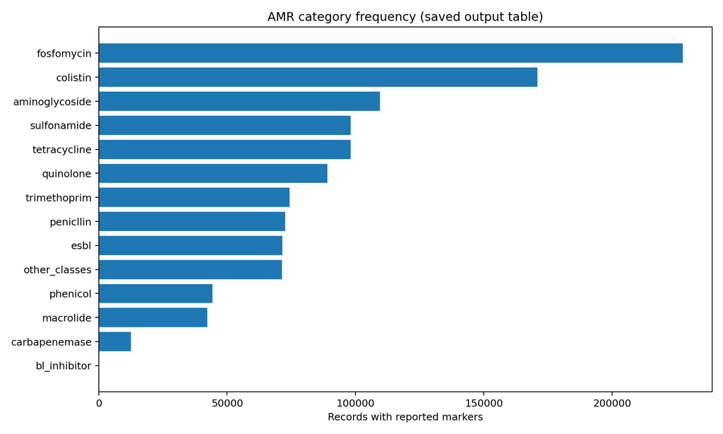

Figure 7. Category frequencies plotted directly from category_frequency.csv.

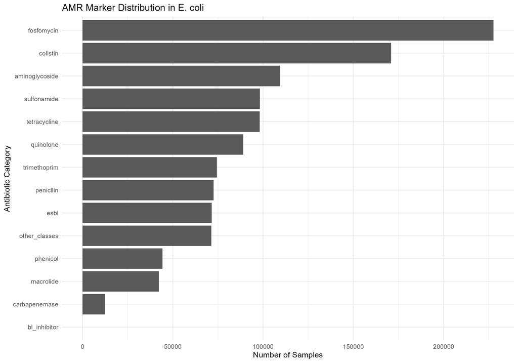

Figure 1. Original AMR category distribution plot supplied in the project.

## 6. Resistance-Associated Determinant Results

The gene_frequency.csv output contains 794 determinant labels. The 20 most frequent are shown below; the complete 794-row table is provided in the appendix and in the downloadable tables folder.

| Determinant | Recorded frequency |
| --- | --- |
| glpT_E448K | 223637 |
| pmrB_Y358N | 116283 |
| sul2 | 68002 |
| aph(6)-Id | 65476 |
| aph(3'')-Ib | 65446 |
| gyrA_S83L | 64599 |
| tet(A) | 63752 |
| blaTEM-1 | 62026 |
| sul1 | 53567 |
| pmrB_E123D | 50368 |
| parC_S80I | 46763 |
| gyrA_D87N | 44546 |
| uhpT_E350Q | 42002 |
| mph(A) | 38604 |
| tet(B) | 35508 |
| aadA1 | 30322 |
| dfrA17 | 29924 |
| blaCTX-M-15 | 27107 |
| aadA5 | 26882 |
| ptsI_V25I | 21885 |

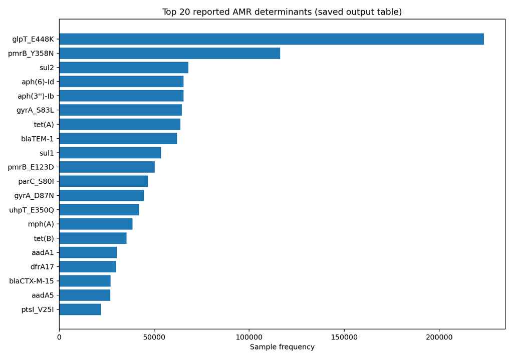

Figure 8. Top 20 determinant frequencies plotted from the saved gene_frequency.csv table.

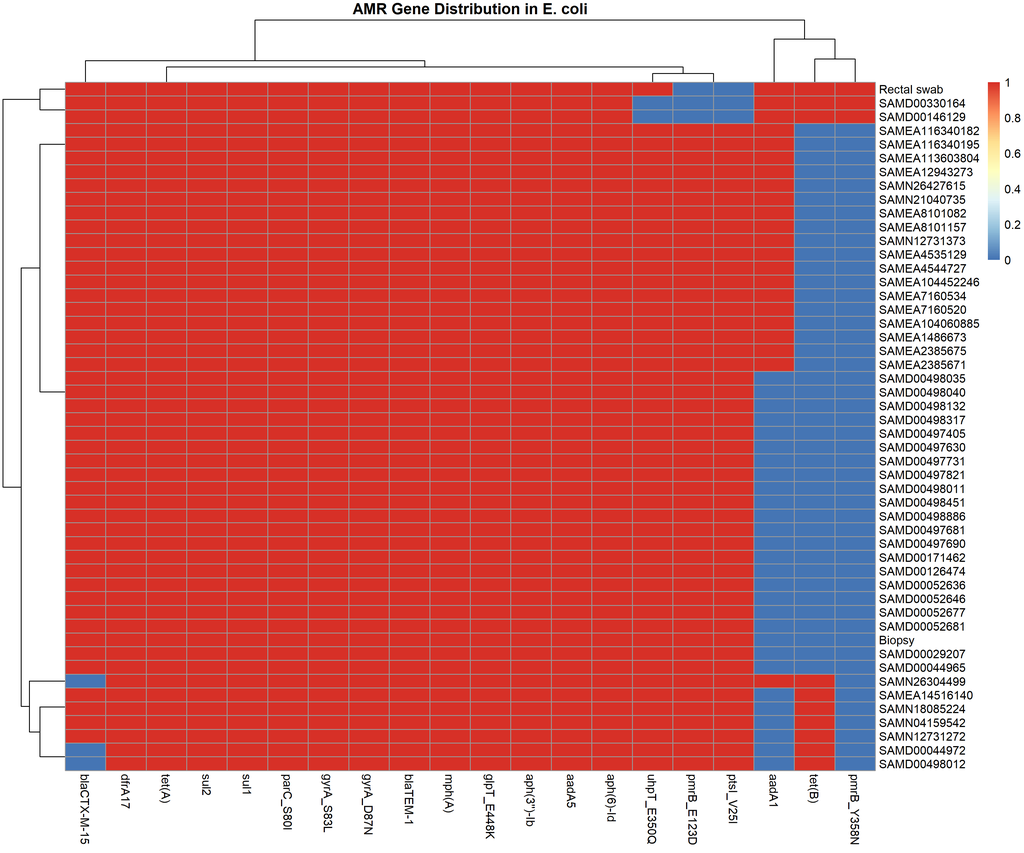

Figure 2. Original AMR gene heatmap.

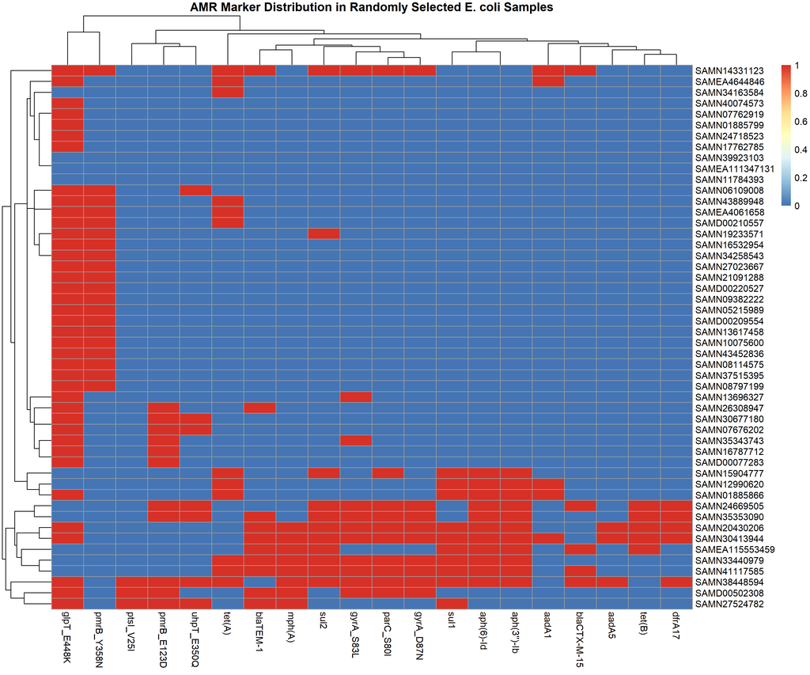

Figure 3. Additional original AMR gene heatmap.

The leading determinant is glpT_E448K (223,637), followed by pmrB_Y358N (116,283), sul2 (68,002), aph(6)-Id (65,476) and aph(3'')-Ib (65,446). These are frequencies in the saved output and should not be interpreted as independently validated phenotypic resistance rates.

## 7. Geographical Analysis

The country_amr_analysis.csv table contains 137 country labels and 223,675 records with country values. The United States contributes the largest number of records (95,008), followed by the United Kingdom (39,418) and Canada (10,361). Percentages are database-record proportions, not national prevalence estimates.

| Country | Total records | Records with markers | Marker-positive (%) |
| --- | --- | --- | --- |
| United States | 95008 | 92514 | 97.37 |
| United Kingdom | 39418 | 38018 | 96.45 |
| Canada | 10361 | 10137 | 97.84 |
| Japan | 8808 | 8688 | 98.64 |
| Australia | 6987 | 6906 | 98.84 |
| Netherlands | 6225 | 6054 | 97.25 |
| Germany | 5620 | 5418 | 96.41 |
| Denmark | 4972 | 4850 | 97.55 |
| China | 3835 | 3741 | 97.55 |
| France | 3830 | 3789 | 98.93 |
| Norway | 3377 | 3322 | 98.37 |
| Switzerland | 2323 | 2237 | 96.30 |
| Belgium | 2096 | 1969 | 93.94 |
| Kenya | 2064 | 1969 | 95.40 |
| Ecuador | 1818 | 1792 | 98.57 |

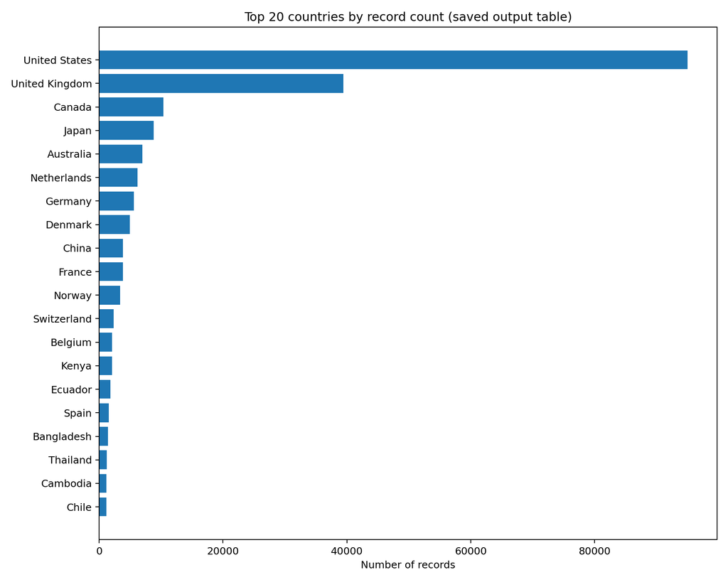

Figure 9. Top 20 countries by record count, generated from the saved country table.

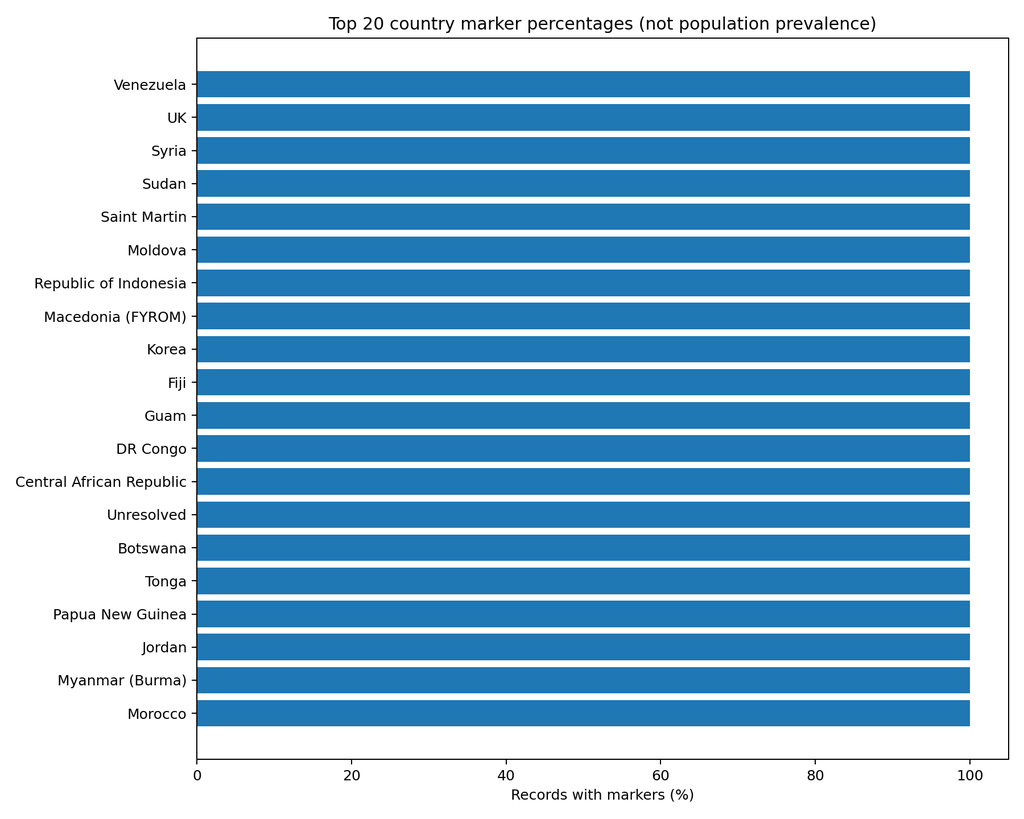

Figure 10. Top 20 country percentages from the saved table; small denominators can produce extreme percentages.

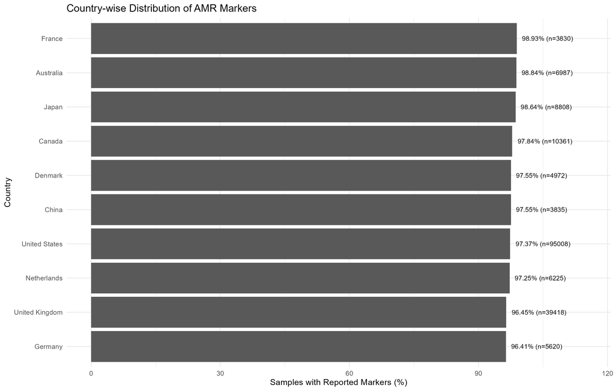

Figure 5. Final country-wise AMR distribution plot supplied in the project.

## 8. Statistical Analysis

### 8.1 Pearson chi-square test

```
	Pearson's Chi-squared test

data:  chi_table
X-squared = 305.7, df = 9, p-value < 2.2e-16
```

The saved test indicates a statistically significant association between the categorical variables used to create chi_table. The exact table construction and expected cell counts were not supplied, so the assumptions should be checked in the analysis script before formal interpretation.

### 8.2 Adjusted Cramer's V

```
Cramer's V (adj.) |       95% CI
--------------------------------
0.04              | [0.04, 1.00]

- One-sided CIs: upper bound fixed at [1.00].
```

The adjusted Cramer's V point estimate of 0.04 indicates a very weak association. The saved 95% interval is exceptionally wide and should be validated using a suitable confidence-interval procedure before being reported as a reliable interval.

### 8.3 Residual analysis

| Country | AMR status | Standardised residual | p-value | Adjusted p-value |
| --- | --- | --- | --- | --- |
| United Kingdom | False | 12.172450 | 4.358018e-34 | 8.716037e-33 |
| United Kingdom | True | -12.172450 | 4.358018e-34 | 8.716037e-33 |
| Australia | True | 8.001635 | 1.227780e-15 | 2.455559e-14 |
| Australia | False | -8.001635 | 1.227780e-15 | 2.455559e-14 |
| Japan | True | 7.819655 | 5.296819e-15 | 1.059364e-13 |
| Japan | False | -7.819655 | 5.296819e-15 | 1.059364e-13 |
| France | True | 6.216640 | 5.079142e-10 | 1.015828e-08 |
| France | False | -6.216640 | 5.079142e-10 | 1.015828e-08 |
| Germany | True | -4.341963 | 1.412154e-05 | 2.824309e-04 |
| Germany | False | 4.341963 | 1.412154e-05 | 2.824309e-04 |
| Canada | True | 3.326499 | 8.794432e-04 | 1.758886e-02 |
| Canada | False | -3.326499 | 8.794432e-04 | 1.758886e-02 |
| Netherlands | False | 0.362066 | 7.173028e-01 | 1.000000e+00 |
| United States | False | -1.346650 | 1.780930e-01 | 1.000000e+00 |
| China | False | -0.865408 | 3.868146e-01 | 1.000000e+00 |
| Denmark | False | -0.976822 | 3.286575e-01 | 1.000000e+00 |
| China | True | 0.865408 | 3.868146e-01 | 1.000000e+00 |
| Denmark | True | 0.976822 | 3.286575e-01 | 1.000000e+00 |
| Netherlands | True | -0.362066 | 7.173028e-01 | 1.000000e+00 |
| United States | True | 1.346650 | 1.780930e-01 | 1.000000e+00 |

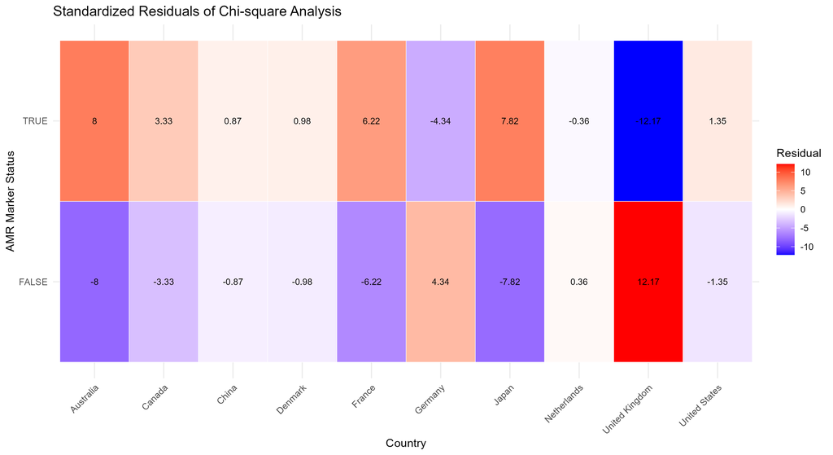

Figure 6. Original chi-square residual plot.

## 9. Discussion

The saved outputs indicate a broad distribution of resistance-associated markers in the AMRnet E. coli records. Fosfomycin and colistin are the most frequently represented categories, while the gene table contains high frequencies for several mutation and acquired determinant labels. The country summary is dominated by records from a small number of countries, and percentages from countries with very small denominators should be interpreted cautiously.

The chi-square result is highly significant, but the Cramer's V estimate is small. This illustrates why effect sizes should accompany p-values, particularly with large datasets. The results are descriptive and do not establish causal relationships or clinical resistance prevalence.

## 10. Limitations

- The analysis is based on a public AMRnet data export; database submissions are not a random or population-representative sample.
- Country percentages are sensitive to uneven record counts, metadata completeness, surveillance coverage, collection period and submission practices.
- The marker category percentages imply a denominator of approximately 259.5 thousand records based on rounded percentages, while missingness percentages imply about 312.8 thousand rows. These are different denominators/eligibility sets; the exact denominator definitions should be documented from the source data and script.
- Rows with missing country are excluded from the country summary; country totals sum to 223,675, not the full dataset row count.
- Exact duplicate-row removal does not prove that all remaining rows represent independent isolates. The sample/isolate identifier should be checked.
- AMR-associated genotype markers do not by themselves establish phenotypic resistance. Laboratory AST results are needed for phenotype confirmation.
- The saved chi-square output does not include the full contingency table or expected cell counts, so assumptions cannot be independently audited from the summary alone.
- The Cramer's V interval [0.04, 1.00] is unusually wide and is reported as saved; its calculation method should be verified before drawing interval-based conclusions.
- The separate ICA 3 script describes an NCBI genome download and AMRFinderPlus workflow but uses placeholder accession metadata and has no corresponding execution outputs in this archive. It is therefore a proposed workflow, not a completed result.

## 11. Recommendations

1. Record the AMRnet snapshot date/version and direct row/unique-isolate counts.
2. Document the exact denominator used for each category percentage and the rule defining marker-positive records.
3. Verify unique sample/isolate identifiers and evaluate duplicate isolates beyond exact duplicate rows.
4. Recalculate the chi-square test from the full contingency table, inspect expected cell counts, and use an appropriate exact/Monte Carlo method if assumptions fail.
5. Validate the Cramer's V confidence interval and report the method.
6. For country comparisons, state numerator and denominator, apply a minimum sample-size threshold, and avoid national prevalence claims.
7. Link genotype predictions to laboratory AST results where available.
8. If genome-based analysis is required, populate ICA 3 metadata with real accessions and provide FASTA, QC and AMRFinderPlus outputs before claiming that workflow was completed.

## 12. Conclusion

The supplied project provides a useful exploratory analysis of AMRnet E. coli records, including marker-category frequencies, determinant frequencies, geographical summaries, missingness and statistical association outputs. The leading category is fosfomycin-associated markers, and glpT_E448K is the most frequent determinant in the saved gene table. The chi-square test is statistically significant, but the adjusted Cramer's V suggests a very weak association. The findings should be interpreted as patterns in a selected public database extract rather than population-level resistance estimates. A clear separation between the completed AMRnet data analysis and the unexecuted NCBI/AMRFinderPlus workflow is essential for an accurate academic submission.

## Appendix A. Full category frequency table

| Antibiotic_Category | Samples_With_Markers | Percentage |
| --- | --- | --- |
| fosfomycin | 227610 | 87.70 |
| colistin | 170919 | 65.86 |
| aminoglycoside | 109548 | 42.21 |
| sulfonamide | 98213 | 37.84 |
| tetracycline | 98166 | 37.83 |
| quinolone | 89077 | 34.32 |
| trimethoprim | 74421 | 28.68 |
| penicllin | 72620 | 27.98 |
| esbl | 71595 | 27.59 |
| other_classes | 71359 | 27.50 |
| phenicol | 44283 | 17.06 |
| macrolide | 42313 | 16.30 |
| carbapenemase | 12508 | 4.82 |
| bl_inhibitor | 0 | 0.00 |

## Appendix B. Full gene frequency table (794 rows)

| Gene | Sample_Frequency |
| --- | --- |
| glpT_E448K | 223637 |
| pmrB_Y358N | 116283 |
| sul2 | 68002 |
| aph(6)-Id | 65476 |
| aph(3'')-Ib | 65446 |
| gyrA_S83L | 64599 |
| tet(A) | 63752 |
| blaTEM-1 | 62026 |
| sul1 | 53567 |
| pmrB_E123D | 50368 |
| parC_S80I | 46763 |
| gyrA_D87N | 44546 |
| uhpT_E350Q | 42002 |
| mph(A) | 38604 |
| tet(B) | 35508 |
| aadA1 | 30322 |
| dfrA17 | 29924 |
| blaCTX-M-15 | 27107 |
| aadA5 | 26882 |
| ptsI_V25I | 21885 |
| parE_I529L | 20741 |
| aadA2 | 18813 |
| aph(3')-Ia | 16873 |
| parC_E84V | 16277 |
| floR | 16223 |
| blaOXA-1 | 15161 |
| catB3 | 14419 |
| aac(6')-Ib-cr5 | 14324 |
| aac(3)-IId | 14168 |
| parE_S458A | 14161 |

[output cut: 764 more lines]

## Appendix C. Full country analysis table (137 rows)

| country_only | Total_Samples | Samples_With_Markers | Percentage |
| --- | --- | --- | --- |
| United States | 95008 | 92514 | 97.37 |
| United Kingdom | 39418 | 38018 | 96.45 |
| Canada | 10361 | 10137 | 97.84 |
| Japan | 8808 | 8688 | 98.64 |
| Australia | 6987 | 6906 | 98.84 |
| Netherlands | 6225 | 6054 | 97.25 |
| Germany | 5620 | 5418 | 96.41 |
| Denmark | 4972 | 4850 | 97.55 |
| China | 3835 | 3741 | 97.55 |
| France | 3830 | 3789 | 98.93 |
| Norway | 3377 | 3322 | 98.37 |
| Switzerland | 2323 | 2237 | 96.30 |
| Belgium | 2096 | 1969 | 93.94 |
| Kenya | 2064 | 1969 | 95.40 |
| Ecuador | 1818 | 1792 | 98.57 |
| Spain | 1592 | 1547 | 97.17 |
| Bangladesh | 1418 | 1416 | 99.86 |
| Thailand | 1237 | 1232 | 99.60 |
| Cambodia | 1207 | 1197 | 99.17 |
| Chile | 1206 | 1191 | 98.76 |
| Malawi | 1141 | 1135 | 99.47 |
| New Zealand | 1088 | 1078 | 99.08 |
| Sweden | 1009 | 991 | 98.22 |
| Singapore | 990 | 977 | 98.69 |
| Pakistan | 827 | 818 | 98.91 |
| Italy | 807 | 769 | 95.29 |
| Vietnam | 782 | 780 | 99.74 |
| Tanzania | 748 | 739 | 98.80 |
| Portugal | 633 | 625 | 98.74 |
| India | 607 | 554 | 91.27 |

[output cut: 107 more lines]

## Appendix D. Full missing-value table (86 variables)

| column | missing_count | missing_percent |
| --- | --- | --- |
| amrnet_id | 0 | 0.00 |
| amrnet_version | 0 | 0.00 |
| amrnetdb_version | 0 | 0.00 |
| amrnetdb_date | 0 | 0.00 |
| enterobase_id | 0 | 0.00 |
| uberstrain | 0 | 0.00 |
| name | 3927 | 1.26 |
| source_niche | 88713 | 28.36 |
| source_type | 82581 | 26.40 |
| source_details | 85537 | 27.35 |
| date | 68892 | 22.02 |
| continent | 54083 | 17.29 |
| country_only | 54477 | 17.42 |
| city | 281774 | 90.08 |
| simple_disease | 301826 | 96.49 |
| bio_project_id | 53053 | 16.96 |
| project_id | 53996 | 17.26 |
| disease | 300349 | 96.02 |
| sample_id | 53265 | 17.03 |
| secondary_sample_id | 54128 | 17.30 |
| date_entered | 0 | 0.00 |
| release_date | 1082 | 0.35 |
| barcode_23 | 0 | 0.00 |
| aminoglycoside | 0 | 0.00 |
| bl_inhibitor | 0 | 0.00 |
| carbapenemase | 0 | 0.00 |
| colistin | 0 | 0.00 |
| esbl | 0 | 0.00 |
| fosfomycin | 0 | 0.00 |
| macrolide | 0 | 0.00 |

[output cut: 56 more lines]

## Appendix E. Full residual analysis table

| Country | AMR_Status | Residual | p_value | adjusted_p |
| --- | --- | --- | --- | --- |
| Australia | False | -8.001635 | 1.227780e-15 | 2.455559e-14 |
| Canada | False | -3.326499 | 8.794432e-04 | 1.758886e-02 |
| China | False | -0.865408 | 3.868146e-01 | 1.000000e+00 |
| Denmark | False | -0.976822 | 3.286575e-01 | 1.000000e+00 |
| France | False | -6.216640 | 5.079142e-10 | 1.015828e-08 |
| Germany | False | 4.341963 | 1.412154e-05 | 2.824309e-04 |
| Japan | False | -7.819655 | 5.296819e-15 | 1.059364e-13 |
| Netherlands | False | 0.362066 | 7.173028e-01 | 1.000000e+00 |
| United Kingdom | False | 12.172450 | 4.358018e-34 | 8.716037e-33 |
| United States | False | -1.346650 | 1.780930e-01 | 1.000000e+00 |
| Australia | True | 8.001635 | 1.227780e-15 | 2.455559e-14 |
| Canada | True | 3.326499 | 8.794432e-04 | 1.758886e-02 |
| China | True | 0.865408 | 3.868146e-01 | 1.000000e+00 |
| Denmark | True | 0.976822 | 3.286575e-01 | 1.000000e+00 |
| France | True | 6.216640 | 5.079142e-10 | 1.015828e-08 |
| Germany | True | -4.341963 | 1.412154e-05 | 2.824309e-04 |
| Japan | True | 7.819655 | 5.296819e-15 | 1.059364e-13 |
| Netherlands | True | -0.362066 | 7.173028e-01 | 1.000000e+00 |
| United Kingdom | True | -12.172450 | 4.358018e-34 | 8.716037e-33 |
| United States | True | 1.346650 | 1.780930e-01 | 1.000000e+00 |

## Appendix F. Reproducibility information

The project includes the following R session information file:

```
R version 4.6.2 (2026-10-29 ucrt)
Platform: x86_64-w64-mingw32/x64
Running under: Windows 11 x64 (build 26300)

Matrix products: default
  LAPACK version 3.12.1

locale:
[1] LC_COLLATE=English_United Kingdom.utf8  LC_CTYPE=English_United Kingdom.utf8
[3] LC_MONETARY=English_United Kingdom.utf8 LC_NUMERIC=C
[5] LC_TIME=English_United Kingdom.utf8

time zone: Asia/Colombo
tzcode source: internal

attached base packages:
[1] stats     graphics  grDevices utils     datasets  methods   base

other attached packages:
 [1] pheatmap_1.0.13 janitor_2.2.1   lubridate_1.9.5 forcats_1.0.1   stringr_1.6.0
 [6] dplyr_1.2.1     purrr_1.2.2     readr_2.2.0     tidyr_1.3.2     tibble_3.3.1
[11] ggplot2_4.0.3   tidyverse_2.0.0

loaded via a namespace (and not attached):
 [1] bit_4.6.0          gtable_0.3.6       crayon_1.5.3       compiler_4.6.2
 [5] tidyselect_1.2.1   parallel_4.6.2     snakecase_0.11.1   scales_1.4.0
 [9] R6_2.6.1           generics_0.1.4     pillar_1.11.1      RColorBrewer_1.1-3
[13] tzdb_0.5.0         rlang_1.3.0        stringi_1.8.9      S7_0.2.2
[17] bit64_4.8.6        timechange_0.4.0   cli_3.6.6          withr_3.0.3
[21] magrittr_2.0.5     grid_4.6.2         vroom_1.7.1        rstudioapi_0.19.0
[25] hms_1.1.4          lifecycle_1.0.5    vctrs_0.7.3        glue_1.8.1
[29] farver_2.1.2       tools_4.6.2        pkgconfig_2.0.3
```

Prepared from the source archive and its saved outputs. Values are reproduced from the included CSV/TXT result files; no unavailable results have been fabricated. Report generated 13 November 2026.